# Blatt06

Seyed Ramtin Hosseini

2025-02-05

## Aufgabe 1

### Installation und Laden der benötigten Pakete

Laden der Daten

```r
videos <- read_csv("data/yt-videos.csv")
```

### a)

Wieviele Videos wurden im Channel insgesamt hochgeladen?

```r
amount_of_uploaded_videos <- nrow(videos)
glue("Anzahl der hochgeladenen Videos im Channel: {amount_of_uploaded_videos}")
```

```
## Anzahl der hochgeladenen Videos im Channel: 90
```

Was ist das meistgeschaute Video?

```r
most_viewed_video <- videos %>% slice_max(views, n = 1)
glue("Das meistgeschaute Video: {most_viewed_video$video_title} mit {most_viewed_video$views} Views.")
```

```
## Das meistgeschaute Video: StatProg1 Session 3.3: Daten Laden mit 262 Views.
```

Was ist das insgesamt am längsten geschaute Video?

```r
most_watched_video <- videos %>% slice_max(watch_time_hours, n = 1)
most_watched_video_time_hours <- round(most_watched_video$watch_time_hours)
glue("Das am längsten geschaute Video: {most_watched_video$video_title} mit {most_watched_video_time_hours} Stunden Watch-Time.")
```

```
## Das am längsten geschaute Video: StatProg1 Session 3.3: Daten Laden mit 34 Stunden Watch-Time.
```

Wieviele Stunden wurden insgesamt Videos geschaut?

```r
total_hours_watched_video <- sum(videos$watch_time_hours, na.rm = TRUE)
glue("Insgesamt wurden {round(total_hours_watched_video)} Stunden Videos geschaut.")
```

```
## Insgesamt wurden 754 Stunden Videos geschaut.
```

### b)

Erstellung einer Funktion zur Analyse Wir erstellen eine Funktion give_answers(), die alle Fragen für einen beliebigen Datensatz beantwortet.

```r
give_answers <- function(dataset) {

  # Anzahl hochgeladener Videos
  amount_of_uploaded_videos <- nrow(dataset)

  # Meistgesehenes Video
  most_viewed_video <- dataset %>% slice_max(views, n = 1)

  # Am längsten geschaute Video
  most_watched_video <- dataset %>% slice_max(watch_time_hours, n = 1)

  # Gesamt-Watch-Time
  total_hours_watched_video <- sum(dataset$watch_time_hours, na.rm = TRUE)

  # Ausgabe
  glue("
  📊 Analyse der YouTube-Daten:
  ------------------------------------
  🏆 Anzahl der hochgeladenen Videos: {amount_of_uploaded_videos}
  🎥 Meistgesehenes Video: {most_viewed_video$video_title} mit {most_viewed_video$views} Views
  ⏳ Am längsten geschaute Video: {most_watched_video$video_title} mit {most_watched_video$watch_time_hours} Stunden Watch-Time
  ⏱️ Gesamt-Watch-Time aller Videos: {round(total_hours_watched_video)} Stunden
  ")
}

# Anwendung der Funktion
give_answers(videos)
```

```
## 📊 Analyse der YouTube-Daten:
## ------------------------------------
## 🏆 Anzahl der hochgeladenen Videos: 90
## 🎥 Meistgesehenes Video: StatProg1 Session 3.3: Daten Laden mit 262 Views
## ⏳ Am längsten geschaute Video: StatProg1 Session 3.3: Daten Laden mit 33.686 Stunden Watch-Time
## ⏱️ Gesamt-Watch-Time aller Videos: 754 Stunden
```

## Aufgabe 2

In dieser Aufgabe nutzen wir **Joins**, um den YouTube-Datensatz nach Videos des Kurses **StatProg1** zu filtern und analysieren die verbleibenden Videos.

### Laden der zusätzlichen Daten

Wir laden nun den Datensatz `yt-statprog1-ids.csv`, der die IDs der Videos enthält, die zu **StatProg1** gehören.

```r
statprog1_ids <- read_csv("data/yt-statprog1-ids.csv")
```

### a)

Wir nutzen einen inner_join(), um nur die Videos aus dem videos-Datensatz zu behalten, die zu StatProg1 gehören. Das Ergebnis speichern wir in statprog1_videos.

```r
statprog1_videos <- inner_join(videos, statprog1_ids, by = "content")

glue("Anzahl der Videos, die zu StatProg1 gehören: {nrow(statprog1_videos)}")
```

```
## Anzahl der Videos, die zu StatProg1 gehören: 48
```

### b)

Wir wenden nun die Funktion give_answers() aus Aufgabe 1 auf statprog1_videos an

```r
give_answers(statprog1_videos)
```

```
## 📊 Analyse der YouTube-Daten:
## ------------------------------------
## 🏆 Anzahl der hochgeladenen Videos: 48
## 🎥 Meistgesehenes Video: StatProg1 Session 3.3: Daten Laden mit 262 Views
## ⏳ Am längsten geschaute Video: StatProg1 Session 3.3: Daten Laden mit 33.686 Stunden Watch-Time
## ⏱️ Gesamt-Watch-Time aller Videos: 546 Stunden
```

### c)

Nun nutzen wir anti_join(), um alle Videos zu erhalten, die nicht zu StatProg1 gehören.

```r
other_videos <- anti_join(videos, statprog1_ids, by = "content")

glue("Anzahl der Videos, die NICHT zu StatProg1 gehören: {nrow(other_videos)}")
```

```
## Anzahl der Videos, die NICHT zu StatProg1 gehören: 42
```

### Aufabe 3

In dieser Aufgabe analysieren wir die Entwicklung der Video-Views über die Zeit.

#### Laden der Daten

```r
daily_views <- read_csv("data/yt-daily-views.csv")
```

### a)

Entwicklung der Views für das meistgesehene Video Wir filtern die Daten für das meistgesehene Video, das wir in Aufgabe 1 ermittelt haben.

```r
daily_views_of_most_viewed <- daily_views %>%
  filter(content == most_viewed_video$content)
```

#### Visualisierung der Views über die Zeit

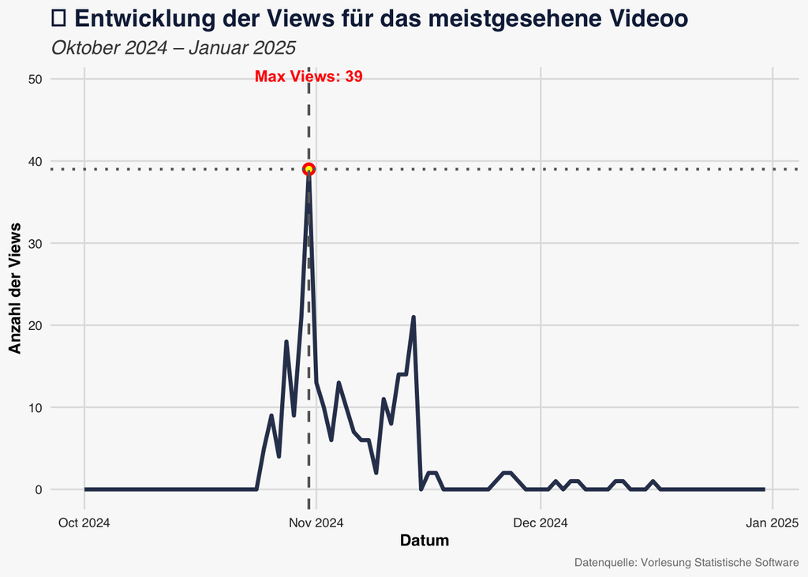

```r
library(ggplot2)

# Maximaler View-Wert & Datum ermitteln
max_point <- daily_views_of_most_viewed %>%
  filter(views == max(views))

# Professionelle Visualisierung
ggplot(daily_views_of_most_viewed, aes(x = date, y = views)) +

  # Basis-Linie für tägliche Views
  geom_line(color = "#112446", size = 1.2, alpha = 0.9) +

  # Maximalen Punkt hervorheben
  geom_point(data = max_point, aes(x = date, y = views),
             color = "red", size = 2, shape = 21, fill = "yellow", stroke = 1.5) +

  # Vertikale Linie für das Datum mit max. Views
  geom_vline(xintercept = as.numeric(max_point$date),
             linetype = "dashed", color = "gray40", size = 0.8) +

  # Horizontale Linie für die maximale Anzahl der Views
  geom_hline(yintercept = max_point$views,
             linetype = "dotted", color = "gray40", size = 0.8) +

  # Annotation für den höchsten Punkt
  annotate("text", x = max_point$date, y = max_point$views + 10,
           label = paste("Max Views:", max_point$views),
           color = "red", fontface = "bold", vjust = -0.5, size = 3.5) +

  # Achsenbeschriftungen & Titel
  labs(
    title = "📈 Entwicklung der Views für das meistgesehene Video",
    subtitle = "Oktober 2024 – Januar 2025",
    x = "Datum",
    y = "Anzahl der Views",
    caption = "Datenquelle: Vorlesung Statistische Software"
  ) +

  # Anpassungen im Theme
  theme_minimal(base_family = "Helvetica") +
  theme(
    plot.title = element_text(size = 15, face = "bold", color = "#112446"),
    plot.subtitle = element_text(size = 12, face = "italic", color = "#444444"),
    axis.title = element_text(size = 10, face = "bold"),
    axis.text = element_text(size = 8, color = "#333333"),
    plot.caption = element_text(size = 7, color = "gray50", hjust = 1),
    panel.grid.major = element_line(color = "#E0E0E0"),
    panel.grid.minor = element_blank(),
    plot.background = element_rect(fill = "#F9F9F9", color = NA),
    panel.border = element_blank()
  ) +

  # Formatierung der Datumsachse
  scale_x_date(date_labels = "%b %Y", date_breaks = "1 month")
```

### b)

Berechnung der Gesamt-Views pro Tag Wir aggregieren die Gesamt-Views über alle Videos für jeden Tag und speichern sie in daily_views_all.

```r
daily_views_all <- daily_views %>%
  group_by(date) %>%
  summarise(views = sum(views, na.rm = TRUE))  # NA-Werte vermeiden

glue("Die Anzahl der Tage mit vorhandenen Daten: {nrow(daily_views_all)}")
```

```
## Die Anzahl der Tage mit vorhandenen Daten: 92
```

## Aufgabe 4

```r
weather <- read_delim("data/weatherdata-2024.csv", delim = ",")
```

### a)

```r
problems(weather)
```

```
## # A tibble: 367 × 5
##      row   col expected  actual    file
##    <int> <int> <chr>     <chr>     <chr>
##  1     3     5 6 columns 5 columns /Users/ramtinhosseini/Desktop/LMU/Semester 3…
##  2     4     5 6 columns 5 columns /Users/ramtinhosseini/Desktop/LMU/Semester 3…
##  3     5     5 6 columns 5 columns /Users/ramtinhosseini/Desktop/LMU/Semester 3…
##  4     6     5 6 columns 5 columns /Users/ramtinhosseini/Desktop/LMU/Semester 3…
##  5     7     5 6 columns 5 columns /Users/ramtinhosseini/Desktop/LMU/Semester 3…
##  6     8     5 6 columns 5 columns /Users/ramtinhosseini/Desktop/LMU/Semester 3…
##  7     9     5 6 columns 5 columns /Users/ramtinhosseini/Desktop/LMU/Semester 3…
##  8    10     5 6 columns 5 columns /Users/ramtinhosseini/Desktop/LMU/Semester 3…
##  9    11     5 6 columns 5 columns /Users/ramtinhosseini/Desktop/LMU/Semester 3…
## 10    12     5 6 columns 5 columns /Users/ramtinhosseini/Desktop/LMU/Semester 3…
## # ℹ 357 more rows
```

```r
weather <- read_delim("data/weatherdata-2024.csv", delim = ",", skip = 2)

#install.packages("janitor")
library(janitor)
```

```r
weather <- weather %>%
  clean_names()
```

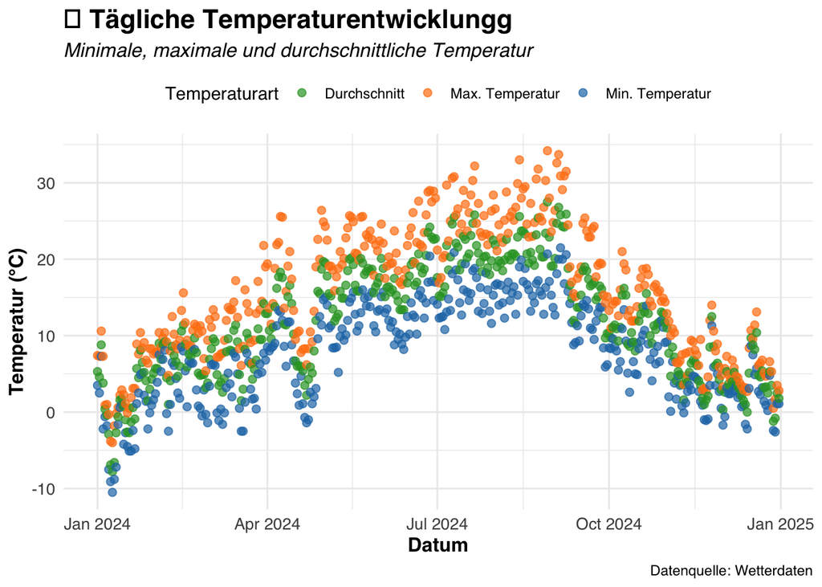

```r
# Data Wrangling
weather_long <- weather %>% pivot_longer(
  cols = c(temperature_2m_max_c, temperature_2m_min_c, temperature_2m_mean_c),
  names_to = "type",
  values_to = "temperature") %>% mutate(
    type = case_when(
    type == "temperature_2m_mean_c" ~ "Durchschnitt",
    type == "temperature_2m_min_c"  ~ "Min.",
    type == "temperature_2m_max_c"  ~ "Max.",
    TRUE ~ type
    )
  )

# Plot
ggplot(
  data = weather_long,
  mapping = aes(
    x = time,
    y = temperature,
    color = type
  )
) +
  geom_point(alpha = 0.7, size = 2) +  # Punkte für Temperaturen
  scale_color_manual(values = c("#2ca02c", "#ff7f0e", "#1f77b4"),  # Blaue, orange und grüne Farbskala
                     labels = c("Durchschnitt", "Max. Temperatur","Min. Temperatur")) +
  labs(
    title = "🌡 Tägliche Temperaturentwicklung",
    subtitle = "Minimale, maximale und durchschnittliche Temperatur",
    x = "Datum",
    y = "Temperatur (°C)",
    color = "Temperaturart",
    caption = "Datenquelle: Wetterdaten"
  ) +
  theme_minimal(base_family = "Helvetica") +
  theme(
    legend.position = "top",
    plot.title = element_text(size = 16, face = "bold"),
    plot.subtitle = element_text(size = 12, face = "italic"),
    axis.title = element_text(size = 12, face = "bold"),
    axis.text = element_text(size = 10)
  )
```

### c)

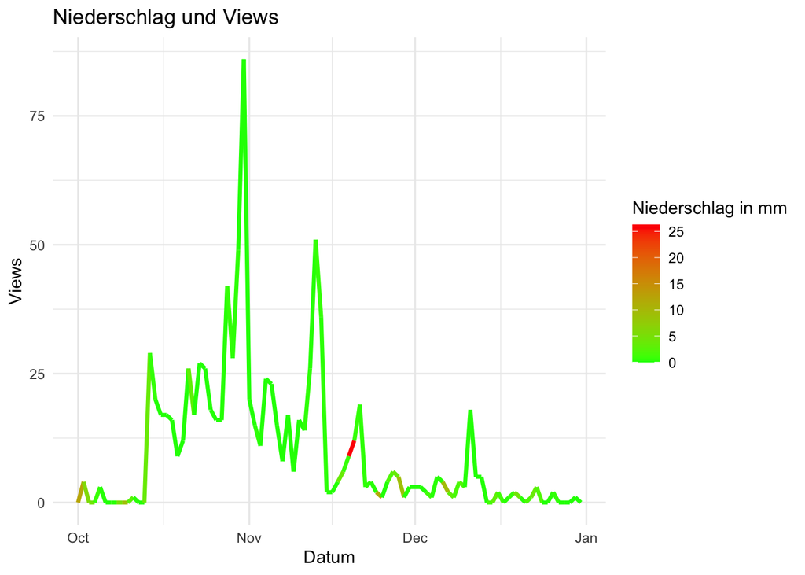

```r
# Data Wrangling
daily_views_all <- daily_views_all %>% rename(time = date)

views_and_weather <- inner_join(daily_views_all, weather_long, by = "time")


# Plot
ggplot(
  data = views_and_weather,
  mapping = aes(
    x = time,
    y = views,
    color = precipitation_sum_mm
  )
) +
  geom_line(linewidth = 1.2) +
  labs(
    title = "Niederschlag und Views",
    x = "Datum",
    y = "Views",
    color = "Niederschlag in mm"
  ) +
  theme_minimal() +
  scale_color_gradient(low = "green", high = "red")
```

### d)

Bei stark schwankenden View-Zahlen lässt sich kein eindeutiger Zusammenhang zwischen Views und Niederschlag feststellen. Zudem kann nicht eindeutig gesagt werden, ob ein erhöhter Niederschlag zu einem Anstieg der View-Zahlen führt, da der Graph sowohl Zuwächse als auch Rückgänge zeigt.